# Nerual Network on PER

Nicholas Burke

06 December 2019

## Introduction

This project will use the computer program R will construct a neural network to analyse which factors go into player efficency rating. Referred to as PER, is the sum of all of a player’s positive accomplishments and subtracts the negative accomplishments, and returns a per-minute rating of a player’s performance. A neural network is a set of connected input and output units in which each connection has a weight associated with it. In this case the inputs are as follows

• Minutes Played

• True Shooting Percentage

• 3 pointer Rate

• Free throw Rate

• Offensive/ Defensive and Total Rebounding Percentage

• Assist Percentage

• Steal Percentage

• Block Percentage

• Turnover Percentage

• Usage Percentage

• Offensive/Defensive and Total Win Shares

• Win Shares Per 48

• Value Over Replacement

With the only output being

• Player Efficency Rating

During the construction of a neural network, the learning phase it adjusts the weights of each input to predict the correct class label of the given inputs. The basic structure of a neural networks consists on an input layer, any number of hidden layers, and an output layer.

The information processing units do not work in a linear manner. In fact, neural network draws its strength from parallel processing of information, which allows it to deal with non-linearity.

The formula for the linear weights using more traditional statistics for PER is as follows

[ (FGM x 85.910) + (Steals x 53.897) + (3PTM x 51.757) + (FTM x 46.845) + (Blocks x 39.190) + (Offensive_Reb x 39.190) + (Assists x 34.677) + (Defensive_Reb x 14.707) - (Foul x 17.174) - (FT_Miss x 20.091) - (FG_Miss x 39.190) - (TO x 53.897) ] x (1 / Minutes).

The goal of this project is to predict the PER using the advance statistics of all the players during the 2018-19 NBA season.

## NBA Statistics in R

```r
library(ballr)
```

This will allow for us to be able to access current and historical basketball data in our console. For the main package ‘ballr’ to work these libraries need to been then called.

```r
library (magrittr)
```

```r
library (ggplot2)
library (janitor)
library (scales)
```

Now that we have called all of the necessary dependencies. We can now view NBA statistics in R.

Let’s call the advanced statistics for the following season

```r
adv_stats<- NBAPerGameAdvStatistics(season = 2019)
head(adv_stats)
```

```
##   rk       player pos age  tm  g   mp  per tspercent x3par   ftr
## 1  1 Álex Abrines  SG  25 OKC 31  588  6.3     0.507 0.809 0.083
## 2  2   Quincy Acy  PF  28 PHO 10  123  2.9     0.379 0.833 0.556
## 3  3 Jaylen Adams  PG  22 ATL 34  428  7.6     0.474 0.673 0.082
## 4  4 Steven Adams   C  25 OKC 80 2669 18.5     0.591 0.002 0.361
## 5  5  Bam Adebayo   C  21 MIA 82 1913 17.9     0.623 0.031 0.465
## 6  6    Deng Adel  SF  21 CLE 19  194  2.7     0.424 0.639 0.111
##   orbpercent drbpercent trbpercent astpercent stlpercent blkpercent
## 1        0.9        7.8        4.2        4.3        1.3        0.9
## 2        2.7       20.1       11.3        8.2        0.4        2.7
## 3        2.6       12.3        7.4       19.8        1.5        1.0
## 4       14.7       14.8       14.7        6.6        2.0        2.4
## 5        9.2       24.0       16.6       14.2        1.8        3.0
## 6        1.6        9.6        5.4        3.4        0.3        1.8
##   tovpercent usgpercent  x  ows dws   ws  ws_48 x_2 obpm dbpm  bpm vorp
## 1        7.9       12.2 NA  0.1 0.6  0.6  0.053  NA -2.4 -0.9 -3.4 -0.2
## 2       15.2        9.2 NA -0.1 0.0 -0.1 -0.022  NA -5.7 -0.3 -5.9 -0.1
## 3       19.7       13.5 NA -0.1 0.2  0.1  0.011  NA -3.1 -1.3 -4.4 -0.3
## 4       12.6       16.4 NA  5.1 4.0  9.1  0.163  NA  0.6  2.1  2.7  3.2
## 5       17.1       15.8 NA  3.4 3.4  6.8  0.171  NA -0.6  3.6  3.0  2.4
## 6       13.7        9.9 NA -0.2 0.0 -0.2 -0.054  NA -5.3 -2.0 -7.3 -0.3
##                        link
## 1 /players/a/abrinal01.html
## 2   /players/a/acyqu01.html
## 3 /players/a/adamsja01.html
## 4 /players/a/adamsst01.html
## 5 /players/a/adebaba01.html
## 6  /players/a/adelde01.html
```

Now let’s examine the structure of the data frame.

```r
str(adv_stats)
```

```
## 'data.frame':    708 obs. of  30 variables:
##  $ rk        : num  1 2 3 4 5 6 7 8 9 10 ...
##  $ player    : chr  "Álex Abrines" "Quincy Acy" "Jaylen Adams" "Steven Adams" ...
##  $ pos       : chr  "SG" "PF" "PG" "C" ...
##  $ age       : num  25 28 22 25 21 21 25 33 21 23 ...
##  $ tm        : chr  "OKC" "PHO" "ATL" "OKC" ...
##  $ g         : num  31 10 34 80 82 19 7 81 10 38 ...
##  $ mp        : num  588 123 428 2669 1913 ...
##  $ per       : num  6.3 2.9 7.6 18.5 17.9 2.7 8.2 22.9 8.1 7.5 ...
##  $ tspercent : num  0.507 0.379 0.474 0.591 0.623 0.424 0.322 0.576 0.418 0.516 ...
##  $ x3par     : num  0.809 0.833 0.673 0.002 0.031 0.639 0.4 0.032 0.308 0.556 ...
##  $ ftr       : num  0.083 0.556 0.082 0.361 0.465 0.111 0.2 0.312 0.308 0.337 ...
##  $ orbpercent: num  0.9 2.7 2.6 14.7 9.2 1.6 4.9 10.3 9.9 0.8 ...
##  $ drbpercent: num  7.8 20.1 12.3 14.8 24 9.6 14.8 19.8 13.7 5.1 ...
##  $ trbpercent: num  4.2 11.3 7.4 14.7 16.6 5.4 9.8 15.1 11.8 3 ...
```

[output cut: 16 more lines]

Here is the summary of the data set

```r
summary(adv_stats)
```

```
##        rk           player              pos                 age
##  Min.   :  1.0   Length:708         Length:708         Min.   :19.00
##  1st Qu.:137.8   Class :character   Class :character   1st Qu.:23.00
##  Median :269.5   Mode  :character   Mode  :character   Median :26.00
##  Mean   :268.4                                         Mean   :26.14
##  3rd Qu.:398.2                                         3rd Qu.:29.00
##  Max.   :530.0                                         Max.   :42.00
##
##       tm                  g               mp              per
##  Length:708         Min.   : 1.00   Min.   :   1.0   Min.   :-38.10
##  Class :character   1st Qu.:19.00   1st Qu.: 245.2   1st Qu.:  9.30
##  Mode  :character   Median :44.00   Median : 788.0   Median : 12.40
##                     Mean   :42.88   Mean   : 972.3   Mean   : 12.75
##                     3rd Qu.:68.00   3rd Qu.:1579.5   3rd Qu.: 16.20
##                     Max.   :82.00   Max.   :3028.0   Max.   : 80.40
##
##    tspercent          x3par             ftr           orbpercent
##  Min.   :0.0000   Min.   :0.0000   Min.   :0.0000   Min.   :  0.00
##  1st Qu.:0.5000   1st Qu.:0.2527   1st Qu.:0.1540   1st Qu.:  1.90
##  Median :0.5440   Median :0.3890   Median :0.2250   Median :  3.30
##  Mean   :0.5315   Mean   :0.3801   Mean   :0.2493   Mean   :  4.98
##  3rd Qu.:0.5810   3rd Qu.:0.5300   3rd Qu.:0.3115   3rd Qu.:  7.00
##  Max.   :1.5000   Max.   :1.0000   Max.   :2.0000   Max.   :100.00
##  NA's   :6        NA's   :6        NA's   :6
##    drbpercent      trbpercent      astpercent      stlpercent
##  Min.   : 0.00   Min.   : 0.00   Min.   : 0.00   Min.   : 0.000
##  1st Qu.: 9.90   1st Qu.: 6.20   1st Qu.: 7.10   1st Qu.: 1.000
##  Median :13.40   Median : 8.70   Median :10.60   Median : 1.400
##  Mean   :15.17   Mean   :10.07   Mean   :13.03   Mean   : 1.484
##  3rd Qu.:19.20   3rd Qu.:12.85   3rd Qu.:17.32   3rd Qu.: 1.825
##  Max.   :90.30   Max.   :51.60   Max.   :73.40   Max.   :12.300
##
##    blkpercent       tovpercent      usgpercent          x
##  Min.   : 0.000   Min.   : 0.00   Min.   : 0.00   Min.   : NA
##  1st Qu.: 0.500   1st Qu.: 9.00   1st Qu.:15.00   1st Qu.: NA
##  Median : 1.200   Median :11.50   Median :17.80   Median : NA
##  Mean   : 1.591   Mean   :12.02   Mean   :18.49   Mean   :NaN
##  3rd Qu.: 2.125   3rd Qu.:14.40   3rd Qu.:21.80   3rd Qu.: NA
##  Max.   :14.800   Max.   :50.00   Max.   :47.20   Max.   : NA
##                   NA's   :6                       NA's   :708
```

[output cut: 9 more lines]

```
##  Min.   : NA   Min.   :-36.100   Min.   :-20.5000   Min.   :-52.300
##  1st Qu.: NA   1st Qu.: -2.900   1st Qu.: -1.7000   1st Qu.: -4.000
##  Median : NA   Median : -1.250   Median : -0.6000   Median : -1.700
##  Mean   :NaN   Mean   : -1.511   Mean   : -0.5787   Mean   : -2.092
##  3rd Qu.: NA   3rd Qu.:  0.125   3rd Qu.:  0.8000   3rd Qu.:  0.200
##  Max.   : NA   Max.   : 38.200   Max.   :  8.5000   Max.   : 44.900
##  NA's   :708
##       vorp             link
##  Min.   :-2.2000   Length:708
##  1st Qu.:-0.1000   Class :character
##  Median : 0.0000   Mode  :character
##  Mean   : 0.4425
##  3rd Qu.: 0.6000
##  Max.   : 9.9000
##
```

Now let’s use only the numerical columns and remove the unnecessary ones

```r
adv_stats2<-na.omit(adv_stats[,c(-1,-2,-3,-4,-5,-6,-20,-25,-30)])
head(adv_stats2)
```

```
##     mp  per tspercent x3par   ftr orbpercent drbpercent trbpercent
## 1  588  6.3     0.507 0.809 0.083        0.9        7.8        4.2
## 2  123  2.9     0.379 0.833 0.556        2.7       20.1       11.3
## 3  428  7.6     0.474 0.673 0.082        2.6       12.3        7.4
## 4 2669 18.5     0.591 0.002 0.361       14.7       14.8       14.7
## 5 1913 17.9     0.623 0.031 0.465        9.2       24.0       16.6
## 6  194  2.7     0.424 0.639 0.111        1.6        9.6        5.4
##   astpercent stlpercent blkpercent tovpercent usgpercent  ows dws   ws
## 1        4.3        1.3        0.9        7.9       12.2  0.1 0.6  0.6
## 2        8.2        0.4        2.7       15.2        9.2 -0.1 0.0 -0.1
## 3       19.8        1.5        1.0       19.7       13.5 -0.1 0.2  0.1
## 4        6.6        2.0        2.4       12.6       16.4  5.1 4.0  9.1
## 5       14.2        1.8        3.0       17.1       15.8  3.4 3.4  6.8
## 6        3.4        0.3        1.8       13.7        9.9 -0.2 0.0 -0.2
##    ws_48 obpm dbpm  bpm vorp
## 1  0.053 -2.4 -0.9 -3.4 -0.2
## 2 -0.022 -5.7 -0.3 -5.9 -0.1
## 3  0.011 -3.1 -1.3 -4.4 -0.3
## 4  0.163  0.6  2.1  2.7  3.2
## 5  0.171 -0.6  3.6  3.0  2.4
## 6 -0.054 -5.3 -2.0 -7.3 -0.3
```

## Training the Model

Now we will begin to train the neural network model firstly we will normalize the data before training a neural network. We will scales the values within the intervals [0,1] to generate better results.

```r
maxs <- apply(adv_stats2,2,max)
maxs
```

```
##         mp        per  tspercent      x3par        ftr orbpercent
##   3028.000     80.400      1.500      1.000      2.000    100.000
## drbpercent trbpercent astpercent stlpercent blkpercent tovpercent
##     90.300     51.600     73.400     12.300     14.800     50.000
## usgpercent        ows        dws         ws      ws_48       obpm
##     47.200     11.400      5.900     15.200      1.261     38.200
##       dbpm        bpm       vorp
##      8.500     44.900      9.900
```

```r
mins <- apply(adv_stats2,2,min)
mins
```

```
##         mp        per  tspercent      x3par        ftr orbpercent
##      1.000    -38.100      0.000      0.000      0.000      0.000
## drbpercent trbpercent astpercent stlpercent blkpercent tovpercent
##      0.000      0.000      0.000      0.000      0.000      0.000
## usgpercent        ows        dws         ws      ws_48       obpm
##      5.700     -2.800     -0.500     -1.700     -0.946    -36.100
##       dbpm        bpm       vorp
##    -20.500    -52.300     -2.200
```

```r
scaled <- as.data.frame(scale(adv_stats2, center = mins, scale = maxs - mins))
```

Here is the scaled new data frame and its first 6 entries

```r
head(scaled)
```

```
##           mp       per tspercent x3par    ftr orbpercent drbpercent
## 1 0.19392137 0.3746835 0.3380000 0.809 0.0415      0.009 0.08637874
## 2 0.04030393 0.3459916 0.2526667 0.833 0.2780      0.027 0.22259136
## 3 0.14106376 0.3856540 0.3160000 0.673 0.0410      0.026 0.13621262
## 4 0.88140073 0.4776371 0.3940000 0.002 0.1805      0.147 0.16389812
## 5 0.63164850 0.4725738 0.4153333 0.031 0.2325      0.092 0.26578073
## 6 0.06375950 0.3443038 0.2826667 0.639 0.0555      0.016 0.10631229
##   trbpercent astpercent stlpercent blkpercent tovpercent usgpercent
## 1 0.08139535 0.05858311 0.10569106 0.06081081      0.158 0.15662651
## 2 0.21899225 0.11171662 0.03252033 0.18243243      0.304 0.08433735
## 3 0.14341085 0.26975477 0.12195122 0.06756757      0.394 0.18795181
## 4 0.28488372 0.08991826 0.16260163 0.16216216      0.252 0.25783133
## 5 0.32170543 0.19346049 0.14634146 0.20270270      0.342 0.24337349
## 6 0.10465116 0.04632153 0.02439024 0.12162162      0.274 0.10120482
##         ows      dws         ws     ws_48      obpm      dbpm       bpm
## 1 0.2042254 0.171875 0.13609467 0.4526507 0.4535666 0.6758621 0.5030864
## 2 0.1901408 0.078125 0.09467456 0.4186679 0.4091521 0.6965517 0.4773663
## 3 0.1901408 0.109375 0.10650888 0.4336203 0.4441454 0.6620690 0.4927984
## 4 0.5563380 0.703125 0.63905325 0.5024921 0.4939435 0.7793103 0.5658436
## 5 0.4366197 0.609375 0.50295858 0.5061169 0.4777927 0.8310345 0.5689300
## 6 0.1830986 0.078125 0.08875740 0.4041686 0.4145357 0.6379310 0.4629630
##        vorp
## 1 0.1652893
## 2 0.1735537
## 3 0.1570248
## 4 0.4462810
## 5 0.3801653
## 6 0.1570248
```

## Train and Test Sets

Now with that the data has been standardized data we can split it into testing and training sets

```r
library(caTools)
advsplit = sample.split(scaled$per, SplitRatio = 0.70)
advtrain = subset(scaled, advsplit == TRUE)
advtest = subset(scaled, advsplit == FALSE)
```

## Training the Model

```r
library(neuralnet)
n <- names(advtrain)
n
```

```
##  [1] "mp"         "per"        "tspercent"  "x3par"      "ftr"
##  [6] "orbpercent" "drbpercent" "trbpercent" "astpercent" "stlpercent"
## [11] "blkpercent" "tovpercent" "usgpercent" "ows"        "dws"
## [16] "ws"         "ws_48"      "obpm"       "dbpm"       "bpm"
## [21] "vorp"
```

```r
f <- as.formula(paste("per ~", paste(n[!n %in% "per"], collapse = " + ")))
f
```

```
## per ~ mp + tspercent + x3par + ftr + orbpercent + drbpercent +
##     trbpercent + astpercent + stlpercent + blkpercent + tovpercent +
##     usgpercent + ows + dws + ws + ws_48 + obpm + dbpm + bpm +
##     vorp
```

## Neural Net Visualization

Now we can create a model with each connection having a weighted value.

```r
nn <- neuralnet(f,data=advtrain,linear.output=TRUE)
```

Now can plot out the neural network

```r
plot(nn)
```

[output not shown]

Positive Values

• Minutes Played

• True Shooting Percentage

• 3 pointer Rate

• Free throw Rate

• Offensive/ Defensive Percentage

• Assist Percentage

• Turnover Percentage

• Offensive Win Shares

• Win Shares Per 48

• Value Over Replacement

Negative Values

• Total Rebounding Percentage

• Steal Percentage

• Block Percentage

• Usage Percentage

• Defensive and Total Win Shares

## Predictions using the Model

```r
predicted.nn.values <- compute(nn,advtest[1:20])
```

Here is the list of the structure of the values

```r
str(predicted.nn.values)
```

```
## List of 2
##  $ neurons   :List of 2
##   ..$ : num [1:193, 1:21] 1 1 1 1 1 1 1 1 1 1 ...
##   .. ..- attr(*, "dimnames")=List of 2
##   .. .. ..$ : chr [1:193] "2" "4" "7" "10" ...
##   .. .. ..$ : chr [1:21] "" "mp" "per" "tspercent" ...
##   ..$ : num [1:193, 1:2] 1 1 1 1 1 1 1 1 1 1 ...
##   .. ..- attr(*, "dimnames")=List of 2
##   .. .. ..$ : chr [1:193] "2" "4" "7" "10" ...
##   .. .. ..$ : NULL
##  $ net.result: num [1:193, 1] 0.201 0.517 0.247 0.229 0.333 ...
##   ..- attr(*, "dimnames")=List of 2
##   .. ..$ : chr [1:193] "2" "4" "7" "10" ...
##   .. ..$ : NULL
```

```r
true.predictions <- predicted.nn.values$net.result*(max(scaled$per)-min(scaled$per))+min(scaled$per)
```

Also can convert the test data.

```r
advtest.r <- (advtest$per)*(max(scaled$per)-min(scaled$per))+min(scaled$per)
```

```r
MSE.nn <- sum((advtest.r - true.predictions)^2)/nrow(advtest)
MSE.nn
```

```
## [1] 0.02858019
```

Now let’s visualize the error in our plot

```r
error.df <- data.frame(advtest.r,true.predictions)
head(error.df)
```

```
##    advtest.r true.predictions
## 2  0.3459916        0.2012964
## 4  0.4776371        0.5166565
## 7  0.3907173        0.2472782
## 10 0.3848101        0.2294139
## 13 0.4329114        0.3326208
## 16 0.3603376        0.2015941
```

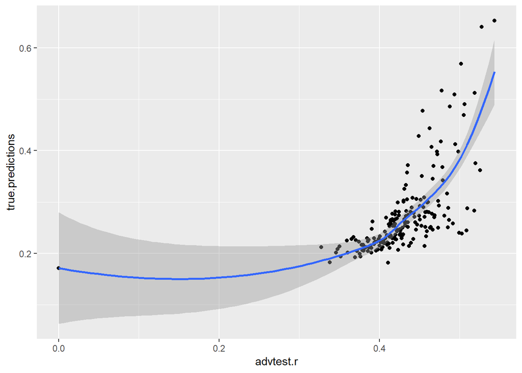

```r
ggplot(error.df,aes(x=advtest.r,y=true.predictions)) + geom_point() + stat_smooth()
```

Now we can use data from any season or team specific to predicted and classify PER.